# 0506

2025-05-06

# **作業說明：**

在行政院性平會有整理相當豐富的[重要性別統計資料庫-國內指標](https://www.gender.ey.gov.tw/gecdb/Stat_Statistics_Field.aspx)。但一來他有層層分類，使用者不見得知道他所需要的資料在哪裡；二來，他有些資料來自於過去的委託計畫，計畫過後就沒再更新。使得帳面上似乎有五百多種性別統計資料，但實際上方便用、能夠用的資料，可能不到一半。不過，即使是這樣，他也值得我們去探索、挖掘。這個作業是希望你去找一個性別資料做資料視覺化，由於在行政院上查找太麻煩了，所以我已經幫你打撈好列在 [gender_index_table_new](https://docs.google.com/spreadsheets/d/159mt94LX-SP10dSwOeSxnjKIwfDKNYhzWmKYwgXhpYo/edit?usp=sharing) 中，且做好了資料類型的分類。請找「type」為「互動式查詢」的資料做觀察並下載。每一個人只需要做一項資料。

- 選擇後請在該項資料的「繪製者（學號_姓名）」欄位紀錄你的學號和姓名，不能與他人重複。✅
- 在你繪製的資料之「資料範圍」，標示該項互動查詢最大可能包含的年份（西元），例如「2012-2022」。注意，並非你實際所繪製的年份，是原始資料中包含的年份。

**作業要求：**

1. 整個作業需要包含一個地圖（**至少是縣市層級**），總共要兩張圖（另一張可以是**不同時間的地圖**，或者是Line Plot或其他）
2. 繪製地圖時，每個縣市或鄉鎮的指標應該是一個綜合性指標，例如「女性／男性」，或者「（女性−男性）／（女性＋男性）」。請自行設計，並於內文中作說明。
3. **新聞標題：**撰寫RMD時，需要以標題一在開頭寫出你認為你的發現可能的新聞標題。
4. **詮釋資料：**撰寫RMD時，在標題底下點列包含以下你所用到的詮釋資料
   1. name：該項指標的名字，為「name」欄位的標題如「居家托育服務登記證書人數」。
   2. 資料範圍：
   3. href：為「href」欄位
   4. def
   5. cat1
   6. cat2
   7. 複分類

**結果詮釋：**就視覺化的結果，撰寫100字的FINDINGS。

# **一、新聞標題：**爺爺們去哪了？性別失衡逾十年的社區關懷訪視

# 二、詮釋資料：

   1.男性的關懷需求較低？還是因為何種原因降低男性接受服務的意願？（有失男性氣魄等）

   2.針對女性為主的地區提供性別客製化的服務（在社區舉辦乳房超音波、子宮頸癌檢查等活動）

# 三、資料製作

### 圖表一：縣市層級地圖

- **步驟解釋：**衛生福利部的社區關懷據點服務人次統計共包含四項服務，分別是「關懷訪視」「電話問安諮詢及轉介服務」「餐飲服務」「健康促進活動」，本作業選擇「關懷訪視」作為主要分析數據，並提去去年（113年度）之資料。總共有兩份資料，分別為男性與女性，兩份整理後的欄位皆包含「縣市別」與「各縣市服務人數」。

```r
#data 113 female data_cleaned113f
f113_data <- read_csv("113female.csv")
```

```
## ──────────────────────────────────────────────────────── Delimiter: "," chr
## (3): 報表產製時間: 2025/05/06 10:30, ...2, ...3
```

```r
data_clean113f <- f113_data[, -1]
data_cleaned113f <- data_clean113f [-c(1:3), ]
colnames(data_cleaned113f) <- c("縣市", "female_count")
data_cleaned113f$female_count <- gsub(",", "", data_cleaned113f$female_count)

# 轉換為數值
data_cleaned113f$female_count <- as.numeric(data_cleaned113f$female_count)

print(data_cleaned113f)
```

```
## # A tibble: 22 × 2
##    縣市   female_count
##    <chr>         <dbl>
##  1 新北市         6734
##  2 臺北市         3269
##  3 桃園市         2776
##  4 臺中市         5001
##  5 臺南市         8249
##  6 高雄市        10219
##  7 宜蘭縣         3157
##  8 新竹縣         1293
##  9 苗栗縣         2333
## 10 彰化縣         5837
## # ℹ 12 more rows
```

```r
#data 113 male data_cleaned113m
m113_data <- read_csv("113male.csv")
```

```
## ──────────────────────────────────────────────────────── Delimiter: "," chr
## (3): 報表產製時間: 2025/05/06 10:30, ...2, ...3
```

```r
data_clean113m <- m113_data[, -1]
data_cleaned113m  <- data_clean113m  [-c(1:3), ]
colnames(data_cleaned113m) <- c("縣市", "male_count")
data_cleaned113m$male_count <- gsub(",", "", data_cleaned113m$male_count)

# 轉換為數值
data_cleaned113m$male_count <- as.numeric(data_cleaned113m$male_count)

print(data_cleaned113m)
```

```
## # A tibble: 22 × 2
##    縣市   male_count
##    <chr>       <dbl>
##  1 新北市       3623
##  2 臺北市       1561
##  3 桃園市       1689
##  4 臺中市       2896
##  5 臺南市       4765
##  6 高雄市       6132
##  7 宜蘭縣       2150
##  8 新竹縣        933
##  9 苗栗縣       1662
## 10 彰化縣       3936
## # ℹ 12 more rows
```

- **步驟解釋：**當順利將檔案整理好後，將兩份資料藉由「縣市」別進行整合，綜合性指標則是計算關懷訪視服務對象之性別比。（方法： （男性人數/女性人數）乘以100)

```r
# chart1 data113
data113 <- merge(data_cleaned113f, data_cleaned113m, by = "縣市")
data113$ratio <- data113$male_count / data113$female_count


# 性別比
data113 $sex_ratio <- data113$ratio * 100
print(data113)
```

```
##      縣市 female_count male_count     ratio sex_ratio
## 1  南投縣         2411       1621 0.6723351  67.23351
## 2  嘉義市          561        264 0.4705882  47.05882
## 3  嘉義縣         1378        688 0.4992743  49.92743
## 4  基隆市         3036       1749 0.5760870  57.60870
## 5  宜蘭縣         3157       2150 0.6810263  68.10263
## 6  屏東縣         3514       1797 0.5113830  51.13830
## 7  彰化縣         5837       3936 0.6743190  67.43190
## 8  新北市         6734       3623 0.5380160  53.80160
## 9  新竹市          755        297 0.3933775  39.33775
## 10 新竹縣         1293        933 0.7215777  72.15777
## 11 桃園市         2776       1689 0.6084294  60.84294
## 12 澎湖縣          929        610 0.6566200  65.66200
## 13 臺中市         5001       2896 0.5790842  57.90842
## 14 臺北市         3269       1561 0.4775161  47.75161
## 15 臺南市         8249       4765 0.5776458  57.76458
## 16 臺東縣         1528        724 0.4738220  47.38220
## 17 花蓮縣         1898        864 0.4552160  45.52160
## 18 苗栗縣         2333       1662 0.7123875  71.23875
## 19 連江縣          173        161 0.9306358  93.06358
## 20 金門縣          963        732 0.7601246  76.01246
## 21 雲林縣         2483       1316 0.5300040  53.00040
## 22 高雄市        10219       6132 0.6000587  60.00587
```

- **步驟解釋：**等等進行結果詮釋時會用到的數據（各縣市服務對象性別平均值），不會用在地圖中。

```r
library(dplyr)

average_sex_ratio <- data113 %>%
  summarise(mean_sex_ratio = mean(sex_ratio, na.rm = TRUE))

print(average_sex_ratio)
```

```
##   mean_sex_ratio
## 1       59.54331
```

- **步驟解釋：**將資料套用至地圖當中，形成縣市層級資料。

```r
library(sf)
library(ggplot2)
library(readr)
library(dplyr)

# 讀取台灣縣市的 Shapefile
taiwan_map <- st_read("data/shapefiles/COUNTY_MOI_1090820.shp")
print(head(taiwan_map))
```

```
## Simple feature collection with 6 features and 4 fields
## Geometry type: MULTIPOLYGON
## Dimension:     XY
## Bounding box:  xmin: 119.9089 ymin: 23.43541 xmax: 124.5611 ymax: 26.38528
## Geodetic CRS:  TWD97
##   COUNTYID COUNTYCODE COUNTYNAME         COUNTYENG
## 1        Z      09007     連江縣 Lienchiang County
## 2        G      10002     宜蘭縣      Yilan County
## 3        N      10007     彰化縣   Changhua County
## 4        M      10008     南投縣     Nantou County
## 5        P      10009     雲林縣     Yunlin County
## 6        C      10017     基隆市      Keelung City
##                         geometry
## 1 MULTIPOLYGON (((119.9645 25...
## 2 MULTIPOLYGON (((121.9597 24...
## 3 MULTIPOLYGON (((120.4566 24...
## 4 MULTIPOLYGON (((121.2709 24...
## 5 MULTIPOLYGON (((120.0811 23...
## 6 MULTIPOLYGON (((121.7102 25...
```

```r
# 資料與地圖資料合併
data113_renamed <- data113 %>%
  rename(COUNTYNAME = `縣市`) # 縣市改名為 "COUNTYNAME"

taiwan_map_merged <- taiwan_map %>%
  right_join(data113_renamed, by = "COUNTYNAME")

# 計算縣市的中心點，用於放置文字標籤
taiwan_map_centroids <- st_centroid(taiwan_map_merged)
```

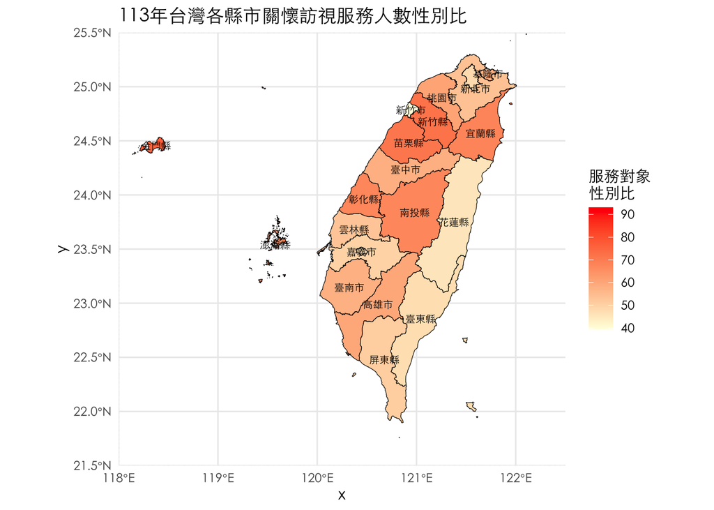

```r
# 繪製地圖
taiwan_map_merged %>%
  ggplot(aes(fill = `sex_ratio`)) +
  geom_sf(color = "black", size = 0.2) +
  scale_fill_gradient(low = "#FFFFE0", high = "red",
                      name = "服務對象\n性別比") +
 geom_sf_text(data = taiwan_map_centroids, aes(label = COUNTYNAME),
               size = 2.5, # 調整文字大小
               nudge_x = 0, # 微調文字水平位置
               nudge_y = 0, # 微調文字垂直位置
               check_overlap = TRUE, # 防止文字重疊
               family = "Heiti TC") +
  coord_sf(
    xlim = c(118, 122.5),
    ylim = c(21.5, 25.5),
    expand = FALSE
  ) +
  labs(
    title = "113年台灣各縣市關懷訪視服務人數性別比"
  ) +
  theme_minimal(base_family = "Heiti TC")
```

#### 圖表二：折線圖

- **步驟解釋：**為了查看關懷訪視服務人數近近十年的成長情形，從政府資料中截取104年至113年全國關懷訪視服務人數的總數及個性別人數，並轉換為數值。

```r
data_total <- read_csv("total.csv")
```

```
## ──────────────────────────────────────────────────────── Delimiter: "," chr
## (4): 報表產製時間: 2025/05/06 13:01, ...2, ...3, ...4
```

```r
data_total2 <- data_total [-c(1:4), ]
colnames(data_total2) <- c("year", "total_count","male_count", "female_count")
data_total2$total_count <- gsub(",", "", data_total2$total_count)
data_total2$male_count <- gsub(",", "", data_total2$male_count)
data_total2$female_count <- gsub(",", "", data_total2$female_count)

data_total2$female_count <- as.numeric(data_total2$female_count)
data_total2$total_count <- as.numeric(data_total2$total_count)
data_total2$male_count <- as.numeric(data_total2$male_count)


print(data_total2)
```

```
## # A tibble: 10 × 4
##    year  total_count male_count female_count
##    <chr>       <dbl>      <dbl>        <dbl>
##  1 104年       80336      33530        46806
##  2 105年       80954      33494        47460
##  3 106年       82565      32088        50477
##  4 107年       82985      32800        50185
##  5 108年       81211      31821        49390
##  6 109年      128235      49421        78814
##  7 110年      115706      44865        70841
##  8 111年       99948      37521        62427
##  9 112年      104914      39363        65551
## 10 113年      108667      40170        68497
```

- **步驟解釋：**製作折線圖

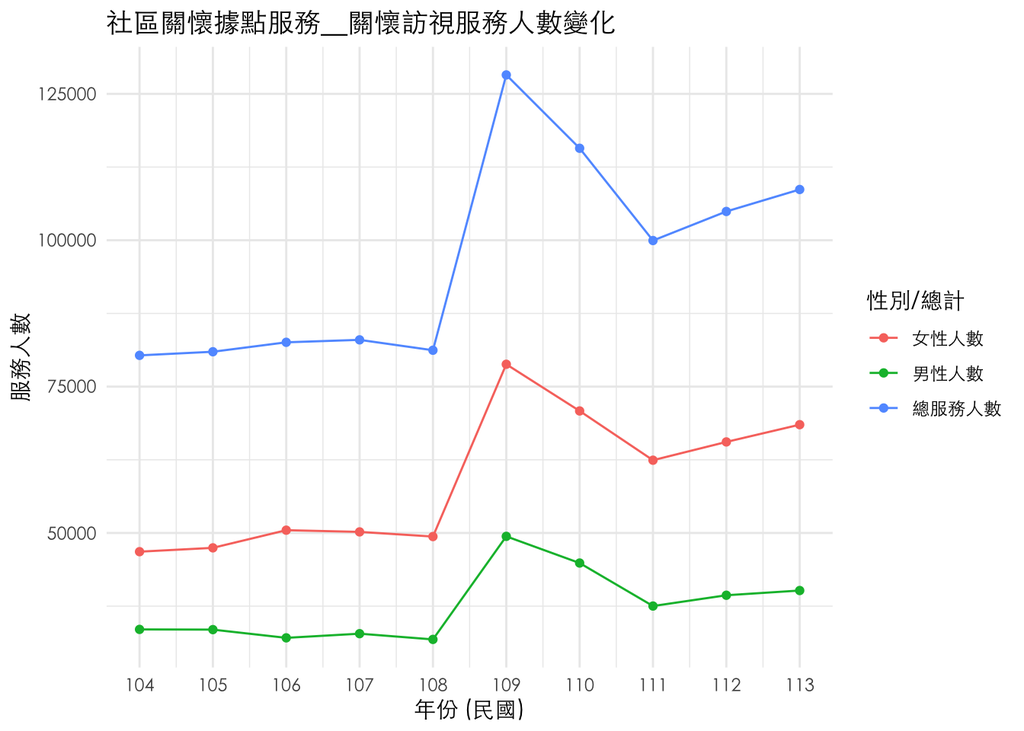

```r
library(ggplot2)
library(dplyr)
library(tidyr)


data_long <- data_total2 %>%
  mutate(year_numeric = as.numeric(gsub("年", "", year))) %>% # 提取數值民國年份
  select(year_numeric, total_count, male_count, female_count) %>%
  pivot_longer(cols = c(total_count, male_count, female_count),
               names_to = "group",
               values_to = "count")

ggplot(data_long, aes(x = year_numeric, y = count, color = group)) +
  geom_line() +
  geom_point() +
  labs(
    title = "社區關懷據點服務＿關懷訪視服務人數變化",
    x = "年份 (民國)",
    y = "服務人數",
    color = "性別/總計"
  ) +
  scale_color_discrete(labels = c("female_count" = "女性人數",
                                  "male_count" = "男性人數",
                                  "total_count" = "總服務人數")) +
  scale_x_continuous(breaks = unique(data_long$year_numeric)) +
  theme_minimal(base_family = "Heiti TC")
```